# Tutorial 09 — Binary Resistance Genotypes

**Prerequisites:** Tutorials 01–08

When using a phage **cocktail** of m species, the bacteria can resist each phage independently, producing 2^m distinct genotypes. Enumerating and parameterising all of these by hand is impractical. `BinaryResistanceGenotypes` (BRG) does this automatically.

**What you will learn**

1. The BRG genotype ordering and labelling convention
2. `BacterialStrain` and `PhageStrain` objects — the preferred constructor
3. Automatic `growth_rates`, `adsorption_rates`, and `mutation_matrix`
4. `equilibrium_initial_condition` — start at mutation-selection balance
5. Phage–antibiotic synergy: evolutionary steering via differential Emax
6. Inspecting what BRG computes before running simulations

## 1 Imports

```python
import numpy as np
import matplotlib.pyplot as plt

from pbisim import PBIModel, solve_ode, DoseEvent, DoseSchedule
from pbisim.strains import (BinaryResistanceGenotypes,
                            BacterialStrain, PhageStrain)
from pbisim.strains.genotypes import Antibiotic
from pbisim.analysis.single import plot_strains

T_END = 72.0
```

## 2 Single-phage BRG (2 strains)

With 1 phage, BRG produces 2 genotypes:

| Index | Label | Meaning |
| --- | --- | --- |
| 0 | `'0'` | WT — susceptible to phi0 |
| 1 | `'1'` | R — resistant to phi0 |

**Fitness cost of resistance** (`fitness_cost`): resistant strains typically grow slower because receptor loss comes with a metabolic penalty. Values of 2–10% per locus are commonly reported.

**Mutation rate** (`mu`): the per-replication rate at which a susceptible bacterium acquires resistance. Typical values: 10⁻⁸ – 10⁻⁶ h⁻¹ for spontaneous phage resistance mutations.

```python
bacteria = BacterialStrain(base_growth_rate=1.0, bacteria_to_resource_ratio=1e9)

phi0 = PhageStrain(
    name="phi0",
    adsorption_s=2e-9,  adsorption_r=2e-11,     # R is 100× less susceptible
    adsorption_dormant_s=2e-11, adsorption_dormant_r=2e-13,
    burst_size_s=50.0,  burst_size_r=40.0,        # slight burst-size reduction in R
    latent_period_s=0.5, latent_period_r=0.5,
    latent_period_dormant_s=1.0, latent_period_dormant_r=1.0,
    fitness_cost=0.06,   # 6% growth-rate penalty for resistance
    mu=5e-8,             # resistance mutation rate  (h⁻¹)
    decay_rate=0.1,
)

brg1 = BinaryResistanceGenotypes.from_strains(
    phages=[phi0], bacteria=bacteria,
)

print("Strain labels:  ", brg1.strain_labels)
print("Growth rates:   ", np.round(brg1.growth_rates, 4))
print("Adsorption (active):")
print("  ", brg1.adsorption_rates)
print("Mutation matrix:")
print(np.array2string(brg1.mutation_matrix, precision=1, suppress_small=True))
```

```
Strain labels:   ['0', '1']
Growth rates:    [1.   0.94]
Adsorption (active):
   [[2.e-09]
 [2.e-11]]
Mutation matrix:
[[-0.  0.]
 [ 0.  0.]]
```

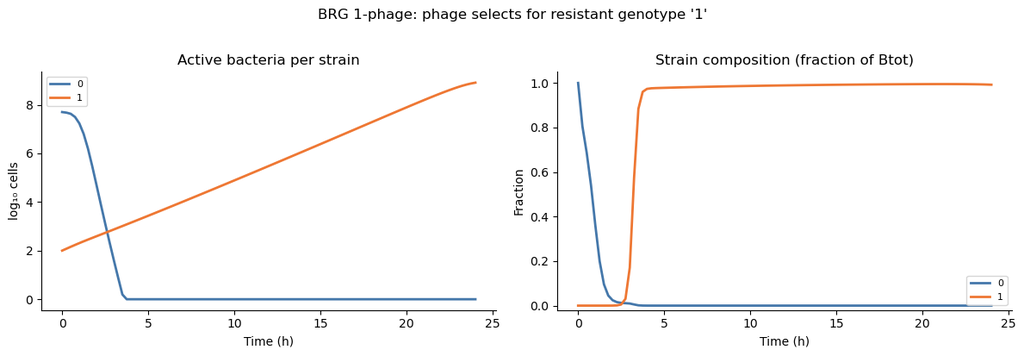

```python
cfg1 = brg1.to_config(n_latent=5, n_depth=1, monod_constant=0.3, recycle_fraction=0.0)

sched1 = DoseSchedule([DoseEvent(time=0, amount=5e8, target="phage", index=0)])
import dataclasses
cfg1_dosed = dataclasses.replace(cfg1, dose_schedule=sched1)

res1 = solve_ode(
    PBIModel(cfg1_dosed, initial_B=np.array([5e7, 1e2]),
             initial_P=np.array([0.0]), initial_S=1.0),
    t_end=24.0, dt=0.25,
)
fig, axes = plot_strains(res1, strain_labels=brg1.strain_labels)
plt.suptitle("BRG 1-phage: phage selects for resistant genotype '1'", y=1.02)
plt.tight_layout()
plt.show()
```

## 3 Two-phage cocktail BRG (4 strains)

With 2 phages, BRG enumerates 4 genotypes:

| Index | Label | Meaning |
| --- | --- | --- |
| 0 | `'00'` | WT — susceptible to phi0 AND phi1 |
| 1 | `'01'` | R_phi1 — susceptible to phi0, resistant to phi1 |
| 2 | `'10'` | R_phi0 — resistant to phi0, susceptible to phi1 |
| 3 | `'11'` | R_both — resistant to both |

**Clinical rationale for a 2-phage cocktail:** phage of different receptor specificities are less likely to be simultaneously evaded. However, using phages with independent resistance mechanisms prevents cross-resistance — a bacterium must acquire two independent mutations to escape the cocktail.

**Cost of double resistance** is multiplicative: a 6%-cost-per-locus bacterium with both resistances grows at `μ × (1-0.06)² ≈ 0.88 × μ` — a significant disadvantage that keeps the double-resistant minority rare in the absence of selective pressure.

```python
phi1 = PhageStrain(
    name="phi1",
    adsorption_s=1.5e-9, adsorption_r=1.5e-11,
    adsorption_dormant_s=1.5e-11, adsorption_dormant_r=1.5e-13,
    burst_size_s=50.0, burst_size_r=40.0,
    latent_period_s=0.5, latent_period_r=0.5,
    latent_period_dormant_s=1.0, latent_period_dormant_r=1.0,
    fitness_cost=0.05,
    mu=3e-8,
    decay_rate=0.1,
)

brg2 = BinaryResistanceGenotypes.from_strains(
    phages=[phi0, phi1], bacteria=bacteria,
)

print("Strain labels:   ", brg2.strain_labels)
print("Growth rates:    ", np.round(brg2.growth_rates, 4))
print("\nAdsorption rates (active, rows=strains, cols=phages):")
print(np.array2string(brg2.adsorption_rates, precision=2))
print("\nMutation matrix (M[dest, origin]):")
print(np.array2string(brg2.mutation_matrix, precision=1, suppress_small=True))
```

```
Strain labels:    ['00', '01', '10', '11']
Growth rates:     [1.    0.95  0.94  0.893]

Adsorption rates (active, rows=strains, cols=phages):
[[2.0e-09 1.5e-09]
 [2.0e-09 1.5e-11]
 [2.0e-11 1.5e-09]
 [2.0e-11 1.5e-11]]

Mutation matrix (M[dest, origin]):
[[-0.  0.  0.  0.]
 [ 0. -0.  0.  0.]
 [ 0.  0. -0.  0.]
 [ 0.  0.  0.  0.]]
```

## 4 `equilibrium_initial_condition` — starting at mutation–selection balance

Seeding only wild-type bacteria creates an artificial lag before resistant mutants appear. In reality, rare resistant variants pre-exist at the mutation–selection balance frequency:

`freq_R ≈ μ / (μ + growth_cost)`

`equilibrium_initial_condition(total_bacteria)` computes this distribution using replicator dynamics. Starting from balance produces more realistic early dynamics where resistant mutants are already present at low but non-zero frequencies.

```
Equilibrium composition (total = 1×10⁷):
  00: 1.000e+07 cells/mL  (99.99986%)
  01: 6.000e+00 cells/mL  (0.00006%)
  10: 8.335e+00 cells/mL  (0.00008%)
  11: 4.065e-06 cells/mL  (0.00000%)
```

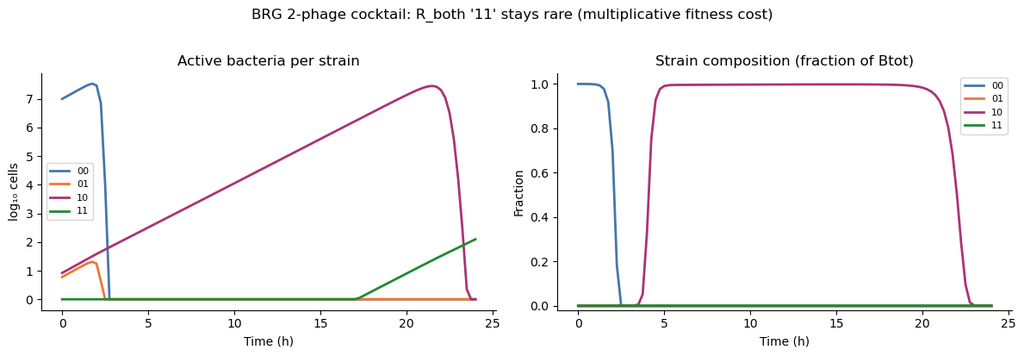

```python
# Stronger phage parameters for clear 24 h dynamics:
# phi0: high adsorption (1e-7), small burst (20), fast lysis (0.5 h)
# phi1: moderate adsorption (1e-8), full burst (50), slower lysis (1 h)
# adsorption_r = 0: perfect resistance (no leaky phage killing of resistant strains)
phi0_s4 = PhageStrain(
    name="phi0",
    adsorption_s=1e-7,  adsorption_r=0.0,
    adsorption_dormant_s=1e-9, adsorption_dormant_r=0.0,
    burst_size_s=20.0,  burst_size_r=20.0,
    latent_period_s=0.5, latent_period_r=0.5,
    latent_period_dormant_s=1.0, latent_period_dormant_r=1.0,
    fitness_cost=0.06, mu=5e-8, decay_rate=0.1,
)
phi1_s4 = PhageStrain(
    name="phi1",
    adsorption_s=1e-8,  adsorption_r=0.0,
    adsorption_dormant_s=1e-10, adsorption_dormant_r=0.0,
    burst_size_s=50.0,  burst_size_r=50.0,
    latent_period_s=1.0, latent_period_r=1.0,
    latent_period_dormant_s=2.0, latent_period_dormant_r=2.0,
    fitness_cost=0.05, mu=3e-8, decay_rate=0.1,
)

brg_s4 = BinaryResistanceGenotypes.from_strains(phages=[phi0_s4, phi1_s4], bacteria=bacteria)

B0_eq = brg_s4.equilibrium_initial_condition(total_bacteria=1e7)
print("Equilibrium composition (total = 1×10⁷):")
for label, count in zip(brg_s4.strain_labels, B0_eq):
    print(f"  {label}: {count:.3e} cells/mL  ({count/1e7*100:.5f}%)")

cfg_s4 = brg_s4.to_config(n_latent=5, n_depth=1, monod_constant=0.3, recycle_fraction=0.0)
sched_s4 = DoseSchedule([
    DoseEvent(time=0, amount=5e3, target="phage", index=0),
    DoseEvent(time=0, amount=5e3, target="phage", index=1),
])
cfg_s4_dosed = dataclasses.replace(cfg_s4, dose_schedule=sched_s4)

res_s4 = solve_ode(
    PBIModel(cfg_s4_dosed, initial_B=B0_eq, initial_P=np.zeros(2), initial_S=1.0),
    t_end=24.0, dt=0.25,
)
fig, axes = plot_strains(res_s4, strain_labels=brg_s4.strain_labels)
plt.suptitle("BRG 2-phage cocktail: R_both '11' stays rare (multiplicative fitness cost)",
             y=1.02)
plt.tight_layout()
plt.show()
```